# Script 9: Fuzzy Regression Discontinuity

Script 9 Spring 2026

# Recap

### Sharp RDD

Last time, we discussed sharp regression discontinuity designs, in which a cut-off perfectly determines the treatment status of units. In simple words: all units on one side of the cut-off are treated, while all units on the other side are not:

$$\operatorname{Pr}\left(D_{i}=1\right)=p\left(X_{i}\right)$$
with

$$p\left(X_{i}\right)= \begin{cases}1 & \text { if } X_{i} \geq X_{0}
\\ 0 & \text { if } X_{i}<X_{0}\end{cases}$$

### Fuzzy RDD

With sharp RDDs being only a special case of regression discontinuity, RDDs are more powerful than that. **Fuzzy RDDs** allow us to estimate causal effects in settings where treatment assignment is not deterministic. The cut-off may not perfectly determine treatment exposure, but it creates a *discontinuity in the probability* of treatment exposure. The cut-off therefore does not perfectly predict treatment status. Still, we can use a fuzzy RDD as long as it introduces a meaningful as-if random discontinuity that we can take advantage of.

$$\begin{aligned}
\lim _{X_{i} \uparrow X_{0}} p\left(X_{i}\right) & \neq \lim _{X_{i}
\downarrow X_{0}} p\left(X_{i}\right)
\end{aligned}$$

As we learned before, we cannot simply ignore treatment uptake as it likely is not random: other (unobserved) covariates might come into play and cause units to take up or reject treatment. In other words, *non-compliance* with treatment assignment is an issue in this case that must be taken into account in order to estimate an unbiased causal effect - this should have you recall Script 7.

In fact, a *fuzzy RDD* simply incorporates an instrumental variable (IV) that is applied to a regression discontinuity. Usually we can use the treatment assignment - i.e., on which side of a cut-off a unit is located - as an instrument for treatment status. Similarly to the IV design, we estimate the *LATE* among compliers - or *CACE* - at the discontinuity. Note that all assumptions of the IV design need to be satisfied here, too. Luckily, this is usually much more credible than in the general IV design as these assumptions must be met *only at the discontinuity*. Extrapolating across the discontinuity, this allows us to estimate the *LATE* for compliers at the discontinuity (practically, we do so extremely close to the threshold):

$$\begin{aligned}
\alpha_{F R D D} &=E\left[Y_{1}-Y_{0} \mid X=c \right] \\
&=\frac{\lim _{x \downarrow c} E[Y \mid X=c]-\lim _{x \uparrow c}
E[Y \mid X=c]}{\lim _{x \downarrow c} E[D \mid X=c]-\lim _{x \uparrow c}
E[D \mid X=c]} \\
&=\frac{\text { outcome discontinuity }}{\text { treatment
discontinuity }} \\
& \approx \frac{E[Y \mid Z=1]-E[Y \mid Z=0]}{E[D \mid Z=1]-E[D \mid
Z=0]}
\end{aligned}$$

This again should sound familiar - the *LATE* among compliers in fuzzy RDDs can be estimated using a 2SLS regression as we will see in the following exercises.

**Before starting this seminar**

1. Create a folder called “script9”
2. Download the data (you can use the button or the one at the top, or read csv files directly from github):
3. Open an R script (or Markdown file) and save it in our “script9” folder.
4. Set your working directory using the setwd() function or by clicking on “More“. For example *setwd(“~/Desktop/Causal Inference/2026/script9”)*
5. Let’s install an load packages that we will be using in this script:

```r
#remotes::install_url("https://cran.r-project.org/src/contrib/Archive/rdd/rdd_0.57.tar.gz") # install an archived version of 'rdd' using the 'remotes' package
library(rdd) # to conduct a density test
library(rdrobust) # to conduct non-parametric estimation
library(rddensity) # to conduct a density test
library(tidyverse)  # ggplot(), %>%, mutate()
library(broom)  # Convert models to data frames
library(rdrobust)  # For robust nonparametric regression discontinuity
library(estimatr)  # Run 2SLS models in one step with iv_robust()
library(modelsummary)  # Create side-by-side regression tables
library(kableExtra)  # Fancy table formatting
library(ggplot2) # to generate plots
library(haven) # to import dta files.
library(wesanderson) # To change the colour scheme of ggplot
```

# Seminar Overview

In this **seminar**, we will cover the following topics:  
1. Familiarise ourselves with the data structure of fuzzy RDD and the substantive interpretation of the estimator.  
2. Visualise discontinuities in terms of treatment and outcome at the cut-off.  
3. Estimate parametric fuzzy RDDs using 2SLS regressions.  
4. Using the `rdrobust` package to estimate non-parametric fuzzy RDDs.  
5. Conduct the relevant robustness/falsification tests such as balance test, placebo outcome and density test.

# Staying in the First League: Parliamentary Representation and the Electoral Success of Small Parties

To familiarize ourselves with fuzzy RDDs, we will be analysing data from the paper Staying in the First League: Parliamentary Representation and the Electoral Success of Small Parties authored by Elias Dinas, Pedro Riera and Nasos Roussias.

In this paper, the authors seek to contribute to answering one of the most essential research questions in party politics: why are some small parties successful whereas other whither away? What accounts for the variation in the trajectories of small parties?

The authors theorise an organisational mechanism that contributes to parties’ success. According to their expectations, *entering parliament* should lead to an increase in a party’s vote share in the subsequent election. This is because being represented in parliament usually comes with a lot of benefits, which are not experienced by parties that are not represented: influence on policy-making, public funding, media visibility, an increase in organisational capacity (staff, etc.) as well as reduced uncertainty about electoral viability and ideological profiles. Conversely, parties that fail to enter parliament do not gain these benefits and might even be abandoned by promising personnel. As you notice, there might be a lot of reasons which make it difficult to isolate a causal effect without an appropriate identification strategy.

In many multi-party systems, there is a legal *threshold* for representation in parliament at the national level, usually in terms of a fixed vote share, which determines whether a party enters parliament or not. The authors exploit the randomness introduced by these electoral thresholds to circumvent endogeneity problems. Clearly, parties are not able to manipulate their vote share with respect to the threshold - at least in functioning democracies. The authors look at countries that have employed a legal threshold of representation at the national level at least once since 1945.

**Why do we need to estimate a *fuzzy RDD* here?** Unlike in the context of sharp RDDs, in this case some candidates make it to parliament even though their party did not pass the threshold - in other words, there is non-compliance with treatment assignment as the discontinuity does not fully determine treatment status. Roughly 20% of electoral systems allow some parties to get into parliament even if they did not meet the threshold - can you think of reasons why?

*Note: Electoral thresholds vary by country, ranging from 0.67%-points to 10%-points. To make observations comparable, the authors standardise electoral results. They use 3.51 as common cut-off point and transform vote shares relative to that scale. Importantly, the relative distance from the threshold remains the same:*

$$\frac{Vote Share_i}{Threshold_i} =
\frac{VoteShare_{i, standardised}}{3.51}$$

We will be using the following variables:

| Variable | Description |
| --- | --- |
| `performance` | This is the *standardised and centred* vote share of party *i* at $t_0$. |
| `treat` | Binary variable that indicates whether the party’s vote share met/exceeded the threshold (=1) or not (=0). |
| `newsuccess` | The party’s vote share in the subsequent election at $t_1$. |
| `treated` | Binary variable indicating whether a party entered parliament (=1) or not (=0) |
| `oldsuccess` | The *standardised and centred* vote share of party *i* at $t_{(-1)}$, which we’ll use as a placebo. |
| `newperc` | Indicates the standardised vote share in absolute terms |
| `seats` | Indicates the number of seats won in an election |
| `established` | Binary variable indicating if a country is an established democracy |
| `oldparty` | Count variable indicating how many elections a party had contested before. |

Now let’s load the data. There are two ways to do this:

You can download the data from github or load the dataset from your laptop using the `read.csv()` function. You can call this data set `enter`.

```r
# Set your working directory
#setwd("~/Desktop/Causal Inference/2026/script9")
#
library(readr)
enter <- read.csv("https://bayreuth-politics.github.io/CI26/data/enter.csv")

#head(enter)
```

Now, let’s see what the data look like. Generate plots using the `rdplot()` function from the `rdrobust` package in order to look at the relation between the running variable and outcome as well as the treatment and running variable.

The syntax is quite simple - see below:

**Exercise 1: Generate plots using the `rdplot(Y, X, ci = 95, binselect = "", subset = condition)` function. Replace X with `enter$performance`. Set the argument `ci` equal to 95, so we can display confidence intervals in each bin. Let’s create an RD plot with evenly-spaced bins by setting the argument `binselect` equal to “es”. Finally, let’s subset the data for parties whose standardised and centred vote share was below 3.51. For this, set the argument `subset` equal to `performance < 3.51`. For more details on this function please see below. Generate two plots: one for the `outcome discontinuity` (with Y being `enter$newsuccess`), and one for the `treatment discontinuity` (with Y being `enter$treated`)**

```r
rdplot(Y, X, c = 0, ci = 95, binselect = "es", subset = Z < condition)
```

| Function/argument | Description |
| --- | --- |
| Y | Y is the dependent variable. |
| X | X is the running variable |
| c | Specify the cut-off (the default is 0) |
| ci | Optional graphical option to display confidence intervals of selected level for each bin |
| binselect | Specifies the procedure to select the number of bins. See options below: |
|  | **es: IMSE-optimal evenly-spaced method using spacings estimators.** |
|  | esmv: mimicking variance evenly-spaced method using spacings estimators. This is the default option. |
|  | qspr: IMSE-optimal quantile-spaced method using polynomial regression. |
| subset | an optional vector specifying a subset of observations to be used. |

**Reveal Answer**

```
[1] "Mass points detected in the running variable."
```

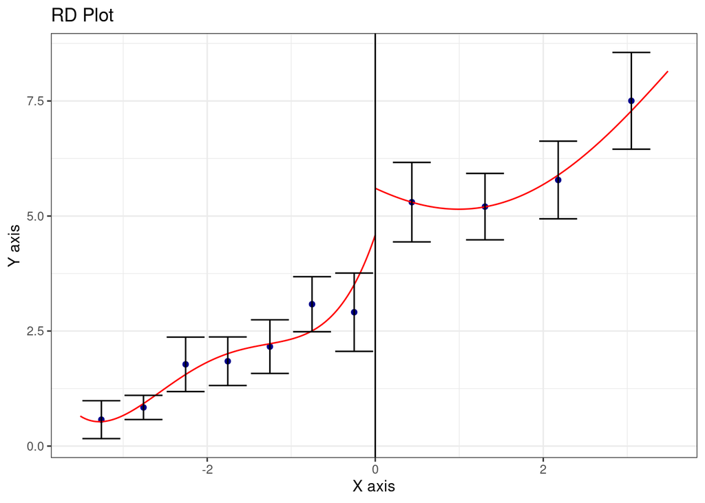

```r
rdplot(enter$newsuccess, enter$performance, ci=95, binselect="es", subset = enter$performance <3.51)
```

Note that it always makes sense to look at the discontinuity in terms of the treatment, too. This will give us a (visual) indication of whether the discontinuity in terms of treatment status is meaningful. You can simply use the `rdplot` command to do this.

```
[1] "Mass points detected in the running variable."
[1] "Warning: not enough variability in the outcome variable above the threshold"
```

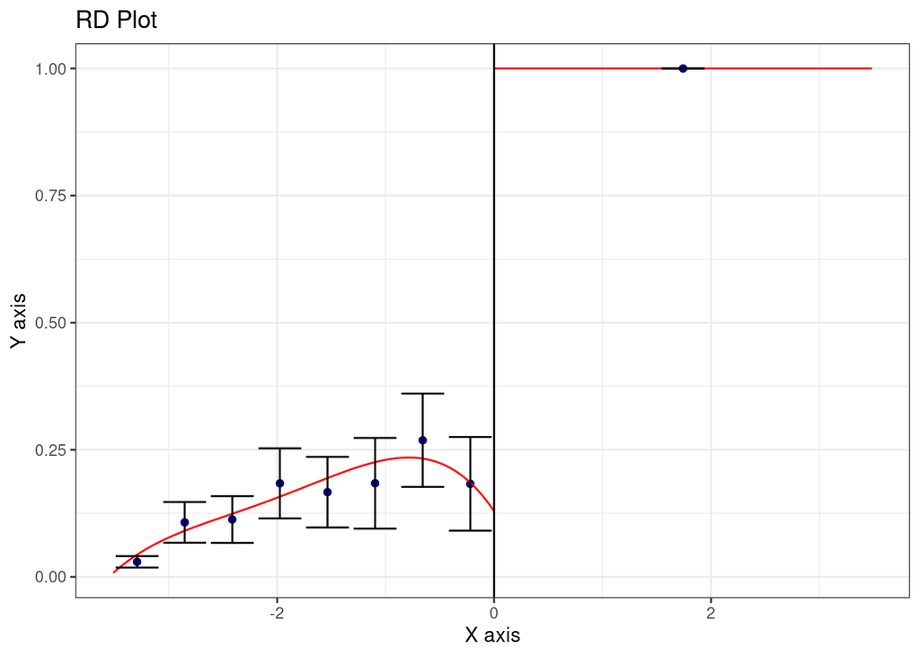

```r
rdplot(enter$treated, enter$performance, ci=95, binselect="es", subset = enter$performance <3.51)
```

As expected, we have perfect compliance above the threshold - and rather strong yet imperfect compliance below the threshold. Without any doubt, we have a meaningful discontinuity in terms of the probability of receiving treatment.

Note that we subset the data to drop observations larger than `3.51%-points` *above* the threshold. This ensures a balanced number of observations (`N`) below and above the cut-off. Even if the running variable is standardised, it cannot take on values smaller than `0` (which after all corresponds to a 0% vote share). To account for this, we mirror this natural boundary above the threshold.

Let’s check that this indeed a fuzzy design. To do so, let’s first create a new variable called `treatment_received`.

**Exercise 2: Create a new variable that is equal to “Treated” if the `treated` variable is equal to 1, and “Not treated” otherwise. You can use the `mutate()` and `ifelse()` function to do this, or you can use simple indexing and subsetting if you prefer. You can see an example below.**

```r
data <- data %>%
  mutate(new_variable = ifelse(variable == 1, "Treated", "Not treated"))
```

**Reveal Answer**

```r
enter <- enter %>%
  dplyr::mutate(treatment_received = ifelse(treated == 1, "Treated", "Not treated"))


# enter$treatment_received <- NA
# enter$treatment_received[enter$treated==1] <- "Treated"
# enter$treatment_received[enter$treated==0] <- "Not Treated"


table(enter$treatment_received)
```

```
Not treated     Treated
       1610        1739
```

Now that we have created this variable, let’s use it to generate other RD plots that will help us identify whether the units actually received the treatment condition that they were assigned to. Let’s use ggplot this time.

**Exercise 3: Generate the following plot:**

- Map data components into the graph `ggplot(aes(x = running variable, y = outcome, colour = as.factor(new received variable)), subset(subset=running variable <3.51), data = data)`
- Add a scatter plot by adding the following function: `geom_point(size = , alpha = )`. Set the `size` argument equal to 1 and the `alpha` argument equal to 0.5.
- Add a linear regression above the threshold using: `geom_smooth(data = filter(subset(data,subset=running variable <3.51), running variable < 0), method = "lm")`
- Add two linear regressions below the threshold using: `geom_smooth(data = filter(subset(data,subset=running variable <3.51), running variable >= 0), method = "lm")`
- Add a vertical line that passes through 0 on the x-axis by setting the `intercept` equal to 0: `geom_vline(xintercept = 0)`
- Change the labels on the y and x axis and add a legend using: `labs(x = "Vote share t0", y = "Vote share t1", title= "", color = "Treated")`
- Change the default colours by adding the Wes Anderson palette or any other of your choosing: `scale_color_manual(values=wes_palette("Darjeeling1"))`

**Reveal Answer**

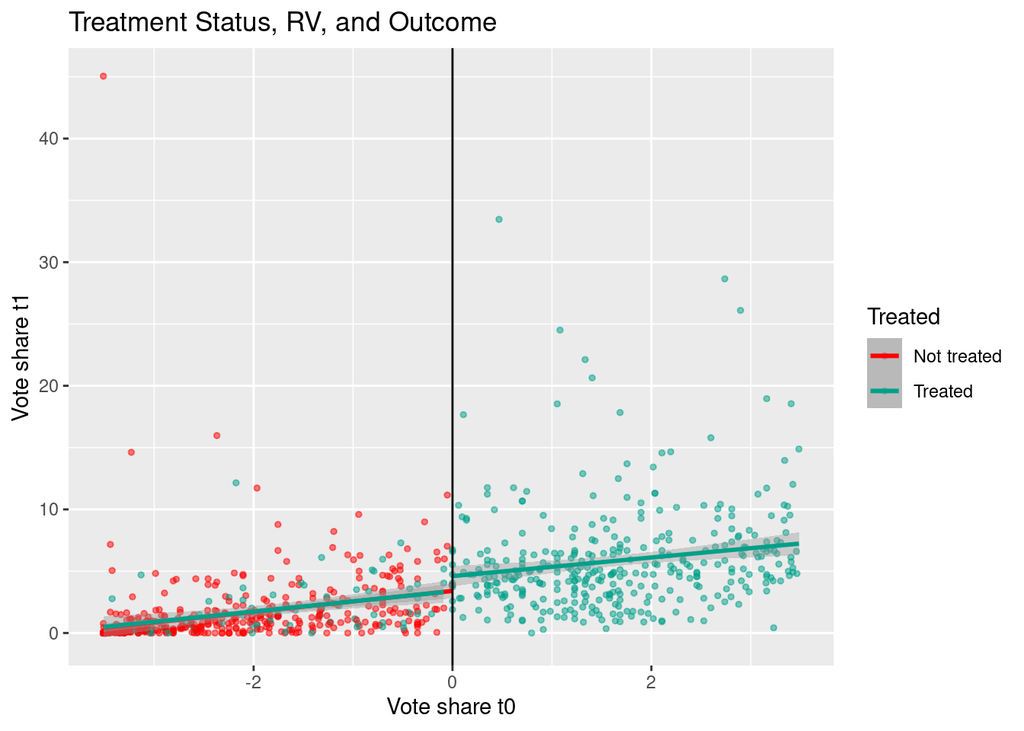

```r
ggplot(subset(enter, subset=performance<3.51), aes(x = performance, y = newsuccess, color = as.factor(treatment_received))) +
  # Make points small and semi-transparent since there are lots of them
  geom_point(size = 1, alpha = 0.5) +
  #  Add a line based on a linear model for the parties meeting the threshold
  geom_smooth(data = filter(subset(enter,subset=performance <3.51), performance < 0), method = "lm") +
  # Add two lines based on a linear model for the parties missing the threshold
 geom_smooth(data = filter(subset(enter,subset=performance <3.51), performance >= 0), method = "lm") +
  geom_vline(xintercept = 0) +
  # Add labels
  labs(x = "Vote share t0", y = "Vote share t1", title = "Treatment Status, RV, and Outcome", color = "Treated") +          scale_color_manual(values=wes_palette("Darjeeling1")) # change the defaults palette.
```

From a quick visual inspection, we can see that we are dealing with a case of one-sided non-compliance. This means that some parties that were below the threshold entered parliament nonetheless - this is what we would expect. Conversely, every party that met its respective threshold entered parliament - as it should do. We see the correlation below the threshold is almost the same for treated and untreated units (in fact, the green line of fit overlays the red one), and almost has the same slope above the threshold. Also, we again see indications of a jump at the discontinuity.

Let’s now calculate the proportion of units where treatment assignment and status are the same, both above and below the threshold. We do this just to know more about the extent of non-compliance we are dealing with.

**Exercise 4: Calculate the proportion of units that comply with their treatment assignment above and below the threshold. You can use simple indexing and subsetting, or feel free to use the instructions and functions below to do this.**

```r
data %>%
  group_by(variable1, variable2) %>%  #
  summarise(count = n()) %>%
  group_by(variable1) %>%
  mutate(prop  = count/ sum(count))
```

- Group observations by using the `group_by()` function and include the following variables: `treated` and `treat`. By executing this operation, we are is creating four groups: 1) Parties below the threshold and not in parliament; 2) Parties below the threshold but represented in parliament; 3) Parties clearing the threshold but not in parliament; 4) Parties clearing the threshold and represented in parliament.
- Add the `summarise()` function and create a new data frame based on the grouping data frame we created just before. Create a new variable called `count` inside of the summarise function. This will be a variable that will store the number of observations in each of the four groups. To do this, we need to add the `n()` function that calculates the number of observations in each group. By adding these two functions, we get the number of observations in each of the four groups (feel free to run just these two lines and see what you get).
- Finally, let’s calculate the *proportion* of compliers above and below the threshold. We can do this by grouping observations by their treatment condition and then using the `sum()` function. We can create a new variable called `prop`. It is based on the number of observations in each sub-group (whether they were above or below the threshold). Then, we divide this number by the total number of observations within each treatment condition using the `sum(count)` function. This will give you the proportion of compliance in either group.

More general details on these functions can be found below:

| Function/argument | Description |
| --- | --- |
| group_by() | Groups observations by the variables included in the function |
| summarise() | Creates a new data frame. It will have one (or more) rows for each combination of grouping variables |
| n() | returns the number of observations in a current group |
| sum() | returns the sum of all the values in its arguments |

**Reveal Answer**

```r
# Use the assignment variable ('treat') or create a new one, which has more informative labels
#enter$AssignedTreatment <-NA
#enter$AssignedTreatment[enter$performance<0] <- FALSE
#enter$AssignedTreatment[enter$performance>=0] <- TRUE

enter %>%
  group_by(treat, treated) %>%
  summarize(count = n()) %>%
  group_by(treat) %>%
  mutate(prop  = count/ sum(count))
```

```
# A tibble: 3 × 4
# Groups:   treat [2]
  treat treated count   prop
  <int>   <int> <int>  <dbl>
1     0       0  1610 0.907
2     0       1   166 0.0935
3     1       1  1573 1
```

We can see the count and proportion of compliance with treatment assignment in each group. As we had already learned, every unit that was assigned to treatment (1573) also received treatment, thus rendering perfect compliance in the treatment group. Conversely, we see that 166 times parties were below the threshold, but ended up in parliament anyway (around `9.3%` of the observations in the control group). We can confirm that we have a case of moderate one-sided non-compliance.

Let’s subset the data for the following analyses. We want to make sure we have a fair comparison between observations below and above the cut-off. Since the standardised and centred `performance` variable cannot have outcomes smaller than `-3,51`, we mirror the data by subsetting positive performance scores:

```r
enter=enter[enter$performance<3.51,]
```

### Fuzzy RDD: Parametric Estimation

As in the case of the sharp RDD, let’s estimate a parametric fuzzy RDD first to make sure we understand the underlying logic - which is based on the instrumental variable design. Remember that in the case of *fuzzy RDDs* we have ‘two events’ of interest. First, **‘treatment assignment’**, which is defined by the running variable exceeding the cut-off, and, secondly, actual **treatment status**. Let formally state that $Z_i$ is an indicator for when $X_{i,\text{centered}}>=0$, i.e., exceeds the cut-off. We can then use this variable to instrument for the endogenous treatment variable $D_{i}$.

The principle is the same as in the IV design: we have an instrument, $Z_i$, that describes assignment to treatment based on an observation’s position relative to the cut-off. We know that the instrument is a strong predictor - as it should be - of the treatment status, $D_i$. We can therefore exploit the random variation (close to the cut-off) introduced by the instrument to predict treatment status in our *first stage* - which you can think of as indicating compliance with the treatment assignment or describing the discontinuity in the probability of receiving treatment:

$$\hat{D_i} = \gamma_0 + \gamma_1
X_{i,centered} + \gamma_2 Z_i + \rho_i$$
for
$$c-h \leq X_i \leq c + h$$

Here, in a simple linear model with a single slope, $\hat{D}$ predicts the treatment status based on assignment to the treatment, ($Z_i$), and the vote share ($X_{i,centered}$) in $t_0$.

The second stage, then, uses the predicted values to calculate the following equation in order to estimate the LATE among compliers at the cut-off:

$$Y_i = \beta_0 + \beta_1 X_{i,centered} +
\beta_2 \hat{D_i} + \epsilon_i$$
for
$$c-h \leq X_i \leq c + h$$

Our coefficient of interest is $\beta_2$, which is the Local Average Treatment Effect (`LATE`) among compliers at the cut-off. Having this in mind, we know we can estimate a parametric fuzzy RDD by specifying a 2SLS regression. This can be done using the packages and commands you already know, such as `iv_robust()`.

**Exercise 5: Estimate a parametric (global) fuzzy RDD model using the `iv_robust()` command. Interpret your findings.**

**Reveal Answer**

```r
model_fuzzy <- iv_robust(
  newsuccess ~ treated + performance | treat + performance,
  data = filter(enter)
)
summary(model_fuzzy)
```

```
Call:
iv_robust(formula = newsuccess ~ treated + performance | treat +
    performance, data = filter(enter))

Standard error type:  HC2

Coefficients:
            Estimate Std. Error t value  Pr(>|t|) CI Lower CI Upper  DF
(Intercept)   2.9523     0.4022   7.341 4.615e-13   2.1631    3.742 930
treated       1.6539     0.6752   2.450 1.449e-02   0.3289    2.979 930
performance   0.7504     0.1340   5.600 2.815e-08   0.4874    1.013 930

Multiple R-squared:  0.3207 ,   Adjusted R-squared:  0.3192
F-statistic: 179.5 on 2 and 930 DF,  p-value: < 2.2e-16
```

Specifying the 2SLS model, we find that the estimated effect is `1.65%-points` on the *standardised scale*. The estimate is also statistically significant, so we conclude that the estimated LATE among compliers is meaningfully different from `0`.

Is this estimate robust though? As you already know, the global parametric estimation has significant weaknesses. Think of our identification assumption for the RDD. In this global model, we have been using *all* observations from the data frame, including those rather far away from the threshold - i.e. those which are not really comparable. Moreover, the parametric model, unlike kernel estimators, does not weight observations. Accordingly, the bias introduced by including the whole range of data is possibly severe. We (likely) have estimated a biased effect here.

Let’s tackle this problem by estimating a more credible parametric fuzzy RDD. We can do so by subsetting the data we input into the regression model.

**Exercise 6: Build upon the same model as above but (i) allow for varying slopes by adding `I(performance*treat)` as a covariate and (ii) only consider parties with vote shares up to `1%` on the standardised scale below/above the threshold. Is this result more credible?**

**Reveal Answer**

```r
model_fuzzy_range <- iv_robust(
  newsuccess ~ treated + performance + I(performance*treat) | treat + performance +I(performance*treat),
  data = filter(enter, performance <= 1, performance>-1)
)
summary(model_fuzzy_range)
```

```
Call:
iv_robust(formula = newsuccess ~ treated + performance + I(performance *
    treat) | treat + performance + I(performance * treat), data = filter(enter,
    performance <= 1, performance > -1))

Standard error type:  HC2

Coefficients:
                       Estimate Std. Error t value  Pr(>|t|) CI Lower CI Upper
(Intercept)               3.236     0.8938   3.620 0.0003744   1.4731   4.9986
treated                   2.586     1.2165   2.126 0.0347403   0.1874   4.9852
performance               1.531     1.1193   1.368 0.1729031  -0.6763   3.7385
I(performance * treat)   -2.826     1.5882  -1.779 0.0767427  -5.9578   0.3063
                        DF
(Intercept)            197
treated                197
performance            197
I(performance * treat) 197

Multiple R-squared:  0.05109 ,  Adjusted R-squared:  0.03664
F-statistic: 7.505 on 3 and 197 DF,  p-value: 8.815e-05
```

This estimator draws a different picture. Our estimated effect is now `2.59%-points` on the standardised scale - this is meaningful and almost as large in magnitude as the standardised threshold itself. The estimate is also statistically significant. Based on this model specification, we can conclude that the LATE among compliers at the cut-off indeed is meaningful.

This model is somewhat more credible than the one we estimated above. Now we are only looking at observations which represent parties with a standardised vote share of up to `1%-point` above or below the standardised threshold. This is more reasonable as these parties should be more comparable. In fact, we find that within this range the actual vote share (`performance`) does not predict the result of the subsequent election in any meaningful way. Within this rather small window, entering parliament seems to drive variation in the subsequent election.

Note that the model still has some disadvantages: we have to specify the functional form of the model and still do not weight observations based on their distance to the cut-off. Estimating non-parametric models helps us calculate even more robust estimates.

### Non-Parametric Fuzzy RDD Estimation

In a first step, let’s ‘emulate’ the parametric model we just specified - this time estimating a non-parametric approach.

Fuzzy estimation with `rdrobust` is - thankfully - relatively straightforward. The syntax is essentially the same as in the case of sharp RDDs, obviously with the exception that we need to specify that our model is supposed to estimate a fuzzy RDD. We can do so using the `fuzzy=` argument to specify the treatment status (`treated` in our case). Importantly, you do not need to specify an instrument (or even create one)! All you need to specify is the column that indicates treatment status, the running variable and the cut-off — `rdrobust` will do all the above/below-the-cut-off instrument stuff behind the scenes for you.

**Exercise 7: Estimate a non-parametric fuzzy RDD with a bandwidth of `h=1` and uniform kernel.**

The syntax of `rdrobust` is pretty similar to the sharp RDD. Recall that the argument `c` specifies the cut-off, while `h` determines the bandwidth. The `fuzzy` argument is sufficient to have `rdrobust` estimate a fuzzy model.

```r
summary(rdrobust(outcome, running_var, c=, fuzzy=treatment_status,   h=))
```

**Reveal Answer**

```r
summary(rdrobust(enter$newsuccess, enter$performance, c=0, fuzzy=enter$treated,  kernel="uniform", h=1))
```

```
[1] "Mass points detected in the running variable."
Call: rdrobust

Number of Obs.                  933
BW type                      Manual
Kernel                      Uniform
VCE method                       NN

Number of Obs.                  568          365
Eff. Number of Obs.              93          108
Order est. (p)                    1            1
Order bias  (q)                   2            2
BW est. (h)                   1.000        1.000
BW bias (b)                   1.000        1.000
rho (h/b)                     1.000        1.000
Unique Obs.                     232          208

=============================================================================
        Method     Coef. Std. Err.         z     P>|z|      [ 95% C.I. ]
=============================================================================
  Conventional     2.586     1.170     2.211     0.027     [0.294 , 4.879]
        Robust         -         -     0.278     0.781    [-2.963 , 3.944]
=============================================================================
```

How does that look like? The estimated effect is equivalent to the one from our (narrow) parametric estimation. Conventional measures of uncertainty - although slightly different from the ones before - also indicate that the effect is significant. Looking at the robust p-values and confidence intervals, however, reveals that we would *not* reject the null hypothesis based on the robust estimation - which indeed are the measures we should base our conclusion on. Here, and solely based on this model, we find that there is no significant LATE among compliers.

As we know, `rdrobust`allows us to specify more appropriate models to estimate our treatment effect. Let’s now make use of these opportunities to run less biased models.

**Exercise 8: Estimate the treatment effect, specifying a triangular kernel and a MSE-optimal bandwidth. Also, cluster standard errors by country using the `cluster=` argument.**

*Note: You can simply add the `cluster` argument and enter the relevant cluster variable. Recall that optimal bandwidths are specified using the `bwselect` argument instead of `h`.*

**Reveal Answer**

```r
summary(rdrobust(enter$newsuccess, enter$performance, c=0, fuzzy=enter$treated,  kernel="triangular", cluster=enter$countrycode, bwselect="mserd"))
```

```
[1] "Mass points detected in the running variable."
Call: rdrobust

Number of Obs.                  933
BW type                       mserd
Kernel                   Triangular
VCE method                       NN

Number of Obs.                  568          365
Eff. Number of Obs.             100          123
Order est. (p)                    1            1
Order bias  (q)                   2            2
BW est. (h)                   1.134        1.134
BW bias (b)                   1.763        1.763
rho (h/b)                     0.643        0.643
Unique Obs.                     232          208

=============================================================================
        Method     Coef. Std. Err.         z     P>|z|      [ 95% C.I. ]
=============================================================================
  Conventional     1.862     1.051     1.772     0.076    [-0.198 , 3.922]
        Robust         -         -     1.332     0.183    [-0.760 , 3.983]
=============================================================================
```

We see that the MSE-optimal bandwidth corresponds to `1.13%-points` on the standardised scale on either side of the cut-off.

The estimated LATE among compliers is `1.86`, not that different from our previous point estimates. Under this model specification, we find that the estimated effect is not statistically significant - the robust confidence interval includes zero, so we cannot conclude that there indeed is a significant effect of entering parliament on parties’ vote share in the subsequent election.

Note that this model uses a triangular kernel and, by clustering standard errors, accounts for non-independence among observations in the same country - for which reason it is somewhat more convincing compared to the models we estimated before.

We can also include covariates. The `rdrobust` package is very flexible in this regard and makes it easy to adjust for them. You can simply add the argument `covs=` and specify the variables you want the model to include.

**Exercise 9: Specify a non-parametric fuzzy RDD with MSE-optimal bandwidth, clustered standard errors and `seats` and `newperc` as covariates. Interpret your result.**

**Reveal Answer**

```r
summary(rdrobust(enter$newsuccess, enter$performance, c=0, fuzzy=enter$treated,  kernel="triangular", cluster=enter$countrycode, covs= enter$seats + enter$newperc,  bwselect="mserd"))
```

```
[1] "Mass points detected in the running variable."
Call: rdrobust

Number of Obs.                  933
BW type                       mserd
Kernel                   Triangular
VCE method                       NN

Number of Obs.                  568          365
Eff. Number of Obs.              99          120
Order est. (p)                    1            1
Order bias  (q)                   2            2
BW est. (h)                   1.111        1.111
BW bias (b)                   1.725        1.725
rho (h/b)                     0.644        0.644
Unique Obs.                     232          208

=============================================================================
        Method     Coef. Std. Err.         z     P>|z|      [ 95% C.I. ]
=============================================================================
  Conventional     2.057     1.087     1.892     0.058    [-0.074 , 4.188]
        Robust         -         -     1.431     0.153    [-0.659 , 4.223]
=============================================================================
```

This again looks interesting - the optimal bandwidth hasn’t changed much, nor did the magnitude of the estimated treatment effect. Similarly to the model we estimated in the exercise before, however, the treatment effect is not statistically significant for robust estimations.

### Sensitivity to Bandwidths

Can we be sure our estimated effect is robust to changing the bandwidth? Let’s see if the estimated effect varies meaningfully. As before, let’s plot the effect over changing bandwidths.

**Exercise 10: Plot the estimated effect and 95% confidence intervals for the model specification from the previous exercise over bandwidths ranging from `0.1` to `3.5` in `0.1%-points` intervals.**

*Note: You migth want to use the following approach*

- *Create a data frame with all variables you need for the plot and an observation for each bandwidth.*
- *Extract the values from the rdrobust output which you need for your plot.*
- *Loop the regression and the extraction of output over the bandwidths indicated in the initial data frame.*
- *Save the output in your loop to the respective row in the data frame.*
- *Plot the output from the newly created data frame.*

**Reveal Answer**

```r
bandwidth <-  seq(from = 0.1, to = 3.5, by = 0.1)  #create a vector with values for each bandwidth you want to estimate

coefficient<- NA
coefficient_corrected <- NA
se <- NA
obs <- NA
bw <- NA
ci_u <- NA
ci_l <- NA
robust_ci_u <- NA
robust_ci_l <- NA

data_extract <- data.frame(bandwidth, coefficient, coefficient_corrected, se, obs, bw, ci_u, ci_l, robust_ci_l, robust_ci_u) # create a data.frame with all variables you want to include in your data set

mserd <- 1.11 # we know this from the model we estimated before

# create a loop for each bandwidth that is indicated by 'i'
for(i in bandwidth){
  rdbw <- rdrobust(enter$newsuccess, enter$performance, c=0, fuzzy=enter$treated,  kernel="triangular", cluster=enter$countrycode, covs= enter$seats + enter$newperc, h=i) # run the model
  # extract the model output (make sure to extract *robust* statistics)
  data_extract$coefficient[data_extract$bandwidth==i]  <- rdbw$coef[1]
  data_extract$coefficient_corrected[data_extract$bandwidth==i]  <- rdbw$coef[3]
  data_extract$se[data_extract$bandwidth==i]  <- rdbw$se[3]
  data_extract$obs[data_extract$bandwidth==i]  <- (rdbw$N_h[1] + rdbw$N_h[2])
  data_extract$bw[data_extract$bandwidth==i]  <- (rdbw$bws[1, 1])
  data_extract$ci_l[data_extract$bandwidth==i]  <- rdbw$ci[1,1]
  data_extract$ci_u[data_extract$bandwidth==i]  <- rdbw$ci[1,2]
  data_extract$robust_ci_l[data_extract$bandwidth==i]  <- rdbw$ci[3,1]
  data_extract$robust_ci_u[data_extract$bandwidth==i]  <- rdbw$ci[3,2]
}
```

[output not shown]

[output cut: 20 more lines]

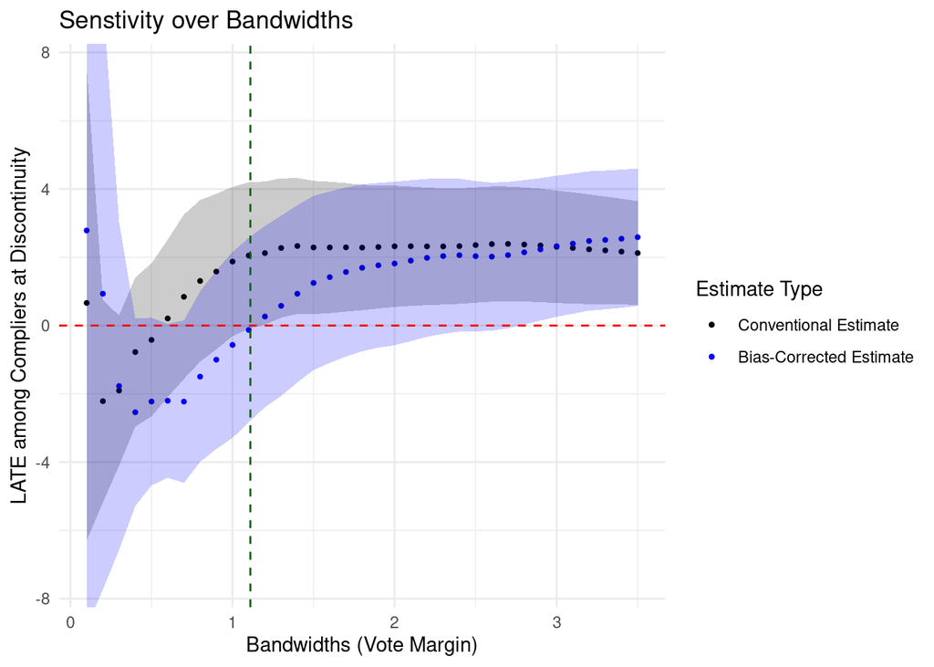

```r
# Make sure the coefficient (and all other values) are numeric
data_extract$coefficient  <- as.numeric(data_extract$coefficient)
data_extract$coefficient_corrected  <- as.numeric(data_extract$coefficient_corrected)


### Plot the sensitivity plot
 # We don't directly specify y here as we will use multiple ones
ggplot(data = data_extract, aes(x = bandwidth)) +
  # This adds the conventional point estimates
  geom_point(aes(y = coefficient, color = "Conventional Estimate"), size = 0.8) +
  # this adds the bias-corrected estimates
  geom_point(aes(y = coefficient_corrected, color = "Bias-Corrected Estimate"), size = 0.8) +
  # this adds the conventional confidence intervals
  geom_ribbon(aes(ymin = ci_l, ymax = ci_u), alpha = 0.2, fill = "black") +
    # this adds the robust confidence intervals
  geom_ribbon(aes(ymin = robust_ci_l, ymax = robust_ci_u), alpha = 0.2, fill = "blue") +
  # a vertical line for our MSE-optimal bandwidth
  geom_vline(xintercept = mserd, color = "darkgreen", linetype = "dashed") +
  # a horizontal line indicate null effect
  geom_hline(yintercept = 0, color = "red", linetype = 2) +
  # we limit the y-axis to values we actually need
  coord_cartesian(ylim = c(-7.5, 7.5)) +
  # and specify colour scale (note that you could have indicates the colors in the lines above, but this way we add a legend)
  scale_color_manual(values = c("Conventional Estimate" = "black", "Bias-Corrected Estimate" = "blue")) +
  theme_minimal() +
  labs(
    y = "LATE among Compliers at Discontinuity",
    x = "Bandwidths (Vote Margin)",
    title = "Senstivity over Bandwidths",
    color = "Estimate Type"
  )
```

This looks interesting - the estimate varies vastly for very narrow bandwidths, but this is expected given the extremely small number of observations that are very close around the threshold. This is not uncommon to see for very small bandwidths - in fact, you will see that most authors omit very narrow bandwidths. However, it even looks like there is almost a significant *negative* treatment effect for bandwidths around `0.5%-points`. This is likely to be driven by specific elections that have a great weight in that window, especially as we can see that this is not at all the case for the conventional point estimate. The rather small number of observations and their structure seems to heavily influence the bias-correction, i.e., impact the quadratic bias-correction. This may be the case due to clustering of data points or a strong influence by single countries. We would want to look into this.

What about the conventional point estimate? It increases roughly until the MSE-optimal bandwidth, and then remains remarkably stable, before starting decaying a little towards the very end of the range. Conventional confidence intervals indicate statistical significance for all bandwidths starting from about the MSE-optimal bandwidths. Note that the authors only present conventional confidence intervals, with their specified algorithms providing an optimal bandwidth of `2.4%-points`.

Here, once more we are being more conservative and transparent by (i) estimating robust confidence intervals and (ii) presenting the results over the full range of possible bandwidths. So, what do we conclude?

Are we reasonably confident that there is a significant effect of entering parliament at $t_0$ on a party’s vote share in the subsequent election ($t_1$)? What would be the effect in substantive terms though?

We know that the threshold (and parties’ vote shares) have been standardised, with the standardised threshold being at `3.51%-points`. We can now write a function to convert the standardised (or synthetic) scale into substantive vote shares based on a country’s electoral threshold:

```r
standardised_to_vote <- function(coef, threshold) {
  vote_share <- coef*threshold/3.51
  return(vote_share)
}
```

**Exercise 11: Based on the treatment effect from our previous model from Exercise 9 (`2.057`), calculate the substantive treatment effect in Turkey, Greece and a country of your choice. For this exercise, let’s forget that the estimated effect was not statistically significant in that particular model - we just want to get an impression of its magnitude.**

**Reveal Answer**

```r
# In Turkey, the threshold is 10%
standardised_to_vote(2.057, 10)
```

```
[1] 5.860399
```

```r
# In Greece, there's only a 3% threshold
standardised_to_vote(2.057, 3)
```

```
[1] 1.75812
```

Recall that standardisation means that we are estimating the effect relative to the threshold. Accordingly, we will get different substantive results for countries with different absolute thresholds. The substantive effect will be roughly $\frac{6}{10}$ of the size of the threshold (because `2.057`/`3.51` $\approx$ 0.6).

We find that the substantive gain of entering parliament in Turkey corresponds to an increase of `5.86%-points` in the subsequent election, whereas it amounts to `1.76%-points` in Greece. What about the other country you chose?

## Falsification tests

### Placebo outcomes

We can conduct multiple tests to find evidence that there is no manipulation of the score around the cut-off. If units cannot precisely manipulate their scores, we further should expect no systematic differences in terms of covariates for units above and below the threshold (we will test this later). We should also expect that there should be no differences in outcomes that should not be affected by the treatment. These outcomes are sometimes called ‘pseudo-outcomes’ in the RDD literature.

One pseudo-outcome that we can use in this study is electoral success (in terms of standardised vote share) in the previous election ($t_{-1}$). The idea here is that current parliamentary representation in period $t_0$ obviously cannot affect electoral performance in $t_{-1}$. Let’s see if this is true.

**Exercise 12: Conduct a placebo outcome test using the placebo outcome variable `oldsuccess`. Use the `rdrobust()` function to perform this test. Set the argument `bwselect` equal to “mserd”. Set the cut-off argument `c` equal to zero. Use the `summary()` command to report the results. What can you conclude based on this test? Does the evidence support the continuity assumption?**

**Reveal Answer**

```r
summary(rdrobust(enter$oldsuccess, enter$performance, c=0, bwselect="mserd"))
```

```
[1] "Mass points detected in the running variable."
Call: rdrobust

Number of Obs.                 1021
BW type                       mserd
Kernel                   Triangular
VCE method                       NN

Number of Obs.                  672          349
Eff. Number of Obs.              94          102
Order est. (p)                    1            1
Order bias  (q)                   2            2
BW est. (h)                   1.003        1.003
BW bias (b)                   1.485        1.485
rho (h/b)                     0.676        0.676
Unique Obs.                     240          196

=============================================================================
        Method     Coef. Std. Err.         z     P>|z|      [ 95% C.I. ]
=============================================================================
  Conventional    -1.713     1.629    -1.052     0.293    [-4.905 , 1.479]
        Robust         -         -    -0.806     0.420    [-5.158 , 2.153]
=============================================================================
```

We find that the local regression estimate is `-1.713` and the robust confidence interval ranges from `-5.158` to `2.153` (the p-value is `0.420`). We thus find that there no is evidence of manipulation of the running variable around the cut-off with respect to previous electoral results - just as expected.

### Placebo cut-offs

As we did in the last script, we can conduct a placebo cut-off test. This test implies looking at the outcome variable but using different cut-offs where we should not expect changes in the outcome. Thus, the estimates from this test should be near zero (and not statistically significant). Again, one **important** step before conducting this test involves subsetting the sample to *either* those observations above the cut-off or those below. We do this to avoid ‘*contamination*’ due to the real treatment effect. It also ensures that the analysis of each placebo cut-off is conducted using only observations with the same treatment status.

Rather than subsetting the data and creating a new data frame, let’s use the `subset` argument in the `rdrobust()` function.

**Exercise 13: Conduct a placebo cut-off test using `-2.95` for the placebo tests below the cut-off. Use the `rdrobust()` function to perform this test. Set the argument `bwselect` equal to “mserd”. Replace the cut-off argument `c` with the value of the placebo cut-off. Add the `subset` argument and set it equal to `data$performance < 0 & data$performance >-3.51.` Use the `summary()` command to report the results. What can you conclude based on this test? Does the evidence support the continuity assumption?**

**Reveal Answer**

```r
summary(rdrobust(enter$newsuccess, enter$performance, c = -2.95, fuzzy=enter$treated, cluster=enter$countrycode,
                 bwselect="mserd", subset=enter$performance < 0 & enter$performance >= -3.51))
```

```
[1] "Mass points detected in the running variable."
Call: rdrobust

Number of Obs.                  521
BW type                       mserd
Kernel                   Triangular
VCE method                       NN

Number of Obs.                  189          332
Eff. Number of Obs.             137           64
Order est. (p)                    1            1
Order bias  (q)                   2            2
BW est. (h)                   0.466        0.466
BW bias (b)                   0.534        0.534
rho (h/b)                     0.872        0.872
Unique Obs.                      63          168

=============================================================================
        Method     Coef. Std. Err.         z     P>|z|      [ 95% C.I. ]
=============================================================================
  Conventional    -0.100     4.453    -0.023     0.982    [-8.828 , 8.628]
        Robust         -         -    -0.193     0.847   [-17.186 , 14.109]
=============================================================================
```

We find that the RD estimate is `-0.100`, which is pretty small. Also, the robust confidence interval reaches from `-17.186` to `14.109`, which clearly includes zero. Thus, this coefficient is not statistically significant. While this does not provide direct evidence in favour of the continuity assumption, it assures us that there seem not to be random jumps in the data, especially if done at several placebo cut-offs. We could conduct further such checks to make sure the data are distributed smoothly, which would tell us that the jump at the discontinuity can be traced back to the actual treatment.

### Sorting

Just as in the case of sharp RDDs, the key identification assumption of fuzzy RDDs is that there is no *sorting* on the running variable as this would violate the assumption of continuity in potential outcomes. From this follows that the running variable must be continuous around the threshold. We can do this using *density checks*. This means we’re looking at the density of the running variable, just as in Script 8. Let’s again use the `rddensity` package to do so.

**Exercise 14: Examine the density of the running variable using the `rddensity` command. Interpret your findings. See an example of the syntax below.**

Doing this is pretty straightforward. You only have to insert the running variable as an argument and, if different from 0, the cut-off. Note that you can optionally specify bandwidths, as above, using the `h` argument. Otherwise, an optimal bandwidth will be specified automatically. You can then save this as an object and run the `summary` command to see the output.

```r
rdd <- rddensity(data$running_variable, c=0)
summary(rdd)
```

**Reveal Answer**

```r
rdd <- rddensity(enter$performance, c=0)
summary(rdd)
```

```
Manipulation testing using local polynomial density estimation.

Number of obs =       2293
Model =               unrestricted
Kernel =              triangular
BW method =           estimated
VCE method =          jackknife

c = 0                 Left of c           Right of c
Number of obs         1776                517
Eff. Number of obs    105                 125
Order est. (p)        2                   2
Order bias (q)        3                   3
BW est. (h)           0.611               0.763

Method                T                   P > |T|
Robust                -0.9864             0.3239


P-values of binomial tests (H0: p=0.5).

Window Length              <c     >=c    P>|T|
0.070     + 0.070           9      15    0.3075
0.130     + 0.140          19      24    0.5424
0.190     + 0.211          27      28    1.0000
0.250     + 0.281          34      39    0.6400
0.310     + 0.351          43      46    0.8323
0.371     + 0.421          62      62    1.0000
0.431     + 0.492          68      72    0.8000
0.491     + 0.562          77      89    0.3933
0.551     + 0.632          94      98    0.8287
0.611     + 0.702         105     104    1.0000
```

This test reveals a p-value of `0.3239`. The null hypothesis of this test is that observations near the cut-off are allocated essentially with a random (or 0.5) probability. Given that we failed to reject the null hypothesis, we can claim there is no evidence of sorting around the cut-off.

Let’s now plot this density test like we did in the script before. Let’s again use the `rdplotdensity` function. Remember that this function uses the output from the `rddensity` command. The syntax is simple:

```r
rdplotdensity([rdd_object] ,[running_var])
```

These are some of the arguments that you can use.

| Argument | Description |
| --- | --- |
| `plotRange` | Indicates starting and end points of the plot |
| `plotN` | Number of grid points used on either side of the cut-off |
| `CIuniform` | True or False. If true, CIs are displayed as continuous bands |

**Exercise 15: Use the `rplotdensity` function to conduct a visual density check. Set the`plotRange` argument equal to `c(-2,2)`. Set the `plotN` argument equal to `25`. Finally set the `CIuniform` equal to TRUE.**

**Reveal Answer**

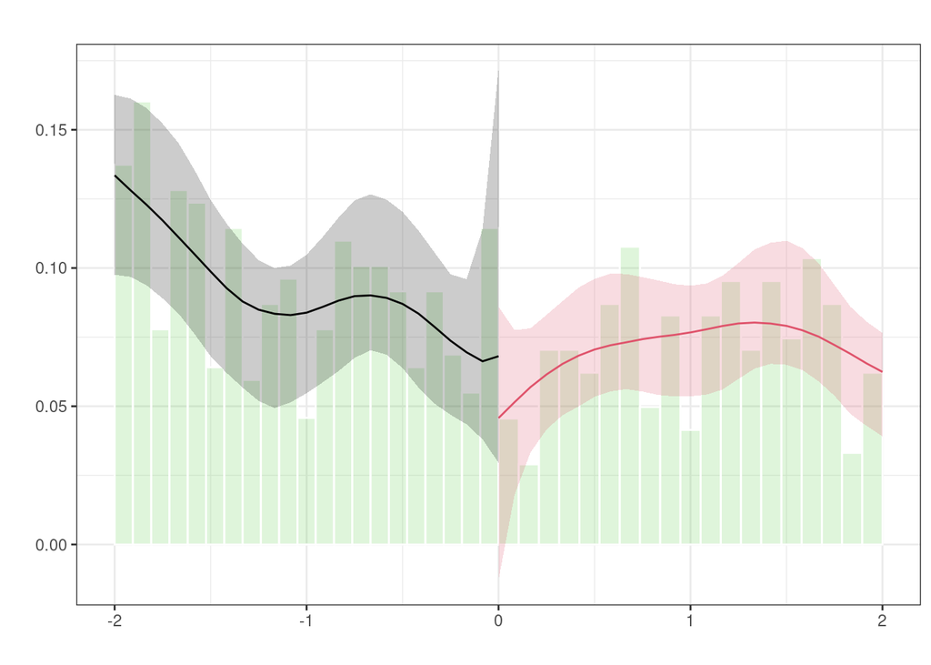

```r
plot_rdd <- rdplotdensity(rdd, enter$performance, plotRange = c(-2, 2), plotN = 25,  CIuniform = TRUE)
```

Again, we find visual evidence for continuity around the cut-off. Now we can be confident about sorting not being a problem with this data.

You can also conduct the same test using the `DCdensity` function from the `rdd` package. To use this command, you need to drop the observations with missing values. You can use the `drop_na(running_variable)` function to achieve this. By and large, it doesn’t matter which function you use - there won’t be meaningful differences unless it’s somewhat of a very close call.

### Balance

Let’s finally conduct a balance test to examine whether, near the cut-off, treated units are similar to control units in terms of observable characteristics. Ideally, we should get an RD estimate, $\tau_{RD}$, which is equal to zero.

**Exercise 16: Let’s check for balance around the cut-off. Use the `rdrobust()` function. Set the cut-off argument `c` equal to 0, and the `bwselect` argument equal to “mserd”. In this case, the outcome variables are the covariates that we want to check for balance. Check if there is balance for the covariate `oldparty`, which is the ‘age’ of the party in terms of previously contested elections. Remember to use the `summary()` command.**

**Reveal Answer**

```r
summary(rdrobust(enter$oldparty, enter$performance, fuzzy=enter$treated, c=0, bwselect="mserd"))
```

```
[1] "Mass points detected in the running variable."
Call: rdrobust

Number of Obs.                 2293
BW type                       mserd
Kernel                   Triangular
VCE method                       NN

Number of Obs.                 1776          517
Eff. Number of Obs.             206          182
Order est. (p)                    1            1
Order bias  (q)                   2            2
BW est. (h)                   1.106        1.106
BW bias (b)                   1.662        1.662
rho (h/b)                     0.666        0.666
Unique Obs.                     454          264

=============================================================================
        Method     Coef. Std. Err.         z     P>|z|      [ 95% C.I. ]
=============================================================================
  Conventional    -0.292     0.569    -0.512     0.608    [-1.408 , 0.824]
        Robust         -         -    -0.292     0.770    [-1.513 , 1.121]
=============================================================================
```

We observe that there is balance for the covariate - just as there should be. We may (and in a real paper should) of course repeat this for other variables as well, especially if we have reason to suspect that there may be imbalance or imbalance in one of the variables would be likely to violate the assumption of continuity in potential outcomes.